# Week 3’s Maximum Speed in Stat 100 Survey Data Problem

In this problem, you are going to look at Stat 100’s survey 1 data in Spring 2017. The csv data file can be downloaded here. Put the file, Stat100_2017spring_survey01.csv, to your R’s working directory and load it with the command

```r
library(tidyverse)
survey <- read_csv("Stat100_2017spring_survey01.csv")
```

The column variables are explained on this webpage.

### a. The `speed` column is the maximum speed (in mph) students claimed they had ever driven. What is the mean and sample standard deviation of `speed`?

Use the `summarize()` function to get the answer:

```r
summarize(survey, mean(speed), sd(speed))
```

```
# A tibble: 1 x 2
  `mean(speed)` `sd(speed)`
          <dbl>       <dbl>
1       80.9076    36.16879
```

### b. Plot a histogram of the maximum speed.

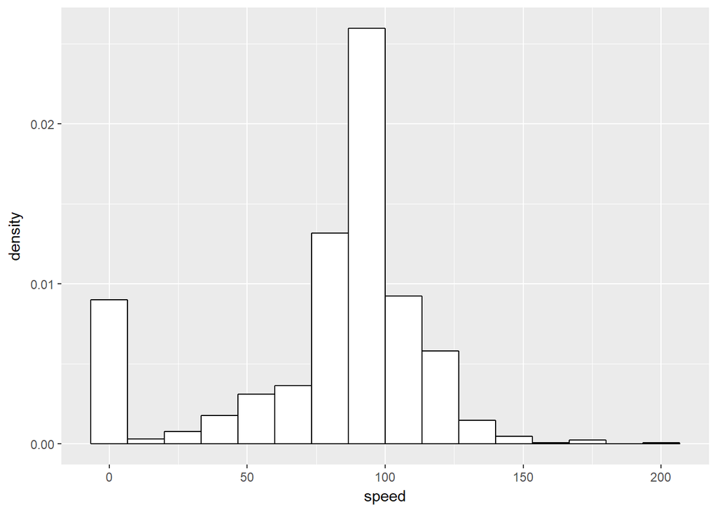

```r
ggplot(survey) + geom_histogram(aes(speed,..density..), bins=16, fill="white", color="black")
```

### c. You should see from the histogram that there are students who said ‘0’, meaning that they had never driven a car. Calculate the total number of students who had never driven a car. Of these students, how many of them were males and how many of them were females?

Use the `filter()` function to subset the tibble:

```r
non_drivers <- filter(survey, speed==0)
```

The number of students who had never driven a car is…

```r
nrow(non_drivers)
```

```
[1] 153
```

To break the number down by gender, we can use `group_by()` and then `summarize()`:

```r
non_drivers %>% group_by(gender) %>% summarize(n())
```

```
# A tibble: 2 x 2
  gender `n()`
   <chr> <int>
1 Female   114
2   Male    39
```

OR use the `table()` function:

```r
table(non_drivers$gender)
```

```
Female   Male
   114     39
```

Note that `n()` is a function in `dplyr` that counts the number of observations in a group. This function can only be used from within `summarise()`, `mutate()` and `filter()`.

### d. From the histogram, you also see that there are a number of students whose maximum driving speeds were quite low. Let’s assume that only those whose maximum driving speeds exceed 30 mph were regular drivers. Create a subset of the `speed` column for regular drivers and then calculate the mean and sample standard deviation.

Use `filter()` to subset the data and then `summarize()` to calculate the statistics.

```r
regular <- filter(survey, speed > 30)
(stats <- summarize(regular, mean=mean(speed), sd=sd(speed)))
```

```
# A tibble: 1 x 2
   mean       sd
  <dbl>    <dbl>
1    93 20.19292
```

### e. Plot a histogram of the maximum speed for the regular drivers. Then superpose a normal curve with the same mean and standard deviation (calculated above).

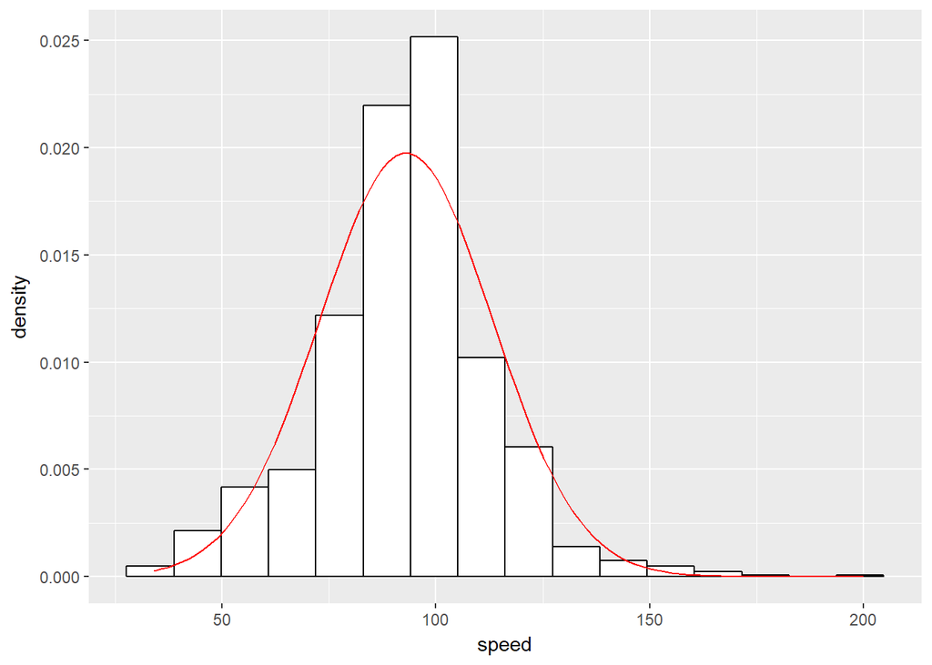

```r
ggplot(regular) +
  geom_histogram(aes(speed,..density..), bins=16, fill="white", color="black") +
  stat_function(fun=dnorm, args=list(mean=stats$mean, sd=stats$sd), color="red")
```